# Whole-genome sequencing reveals distinct mutational mechanisms shaping endometrial cancer

Tongwu Zhang

2026-02-09

## 1 Overview

This R Markdown document reproduces the main analyses and figures for TCGA-UCEC WGS dataset

Manuscript title: Whole-genome sequencing reveals distinct mutational mechanisms shaping endometrial cancer

## 2 Fig. 1: Whole-genome sequencing defines distinct genomic architectures across UCEC subtypes.

## 3 Load Required Libraries and Set Plotting Styles

(You may need to install some packages if missing)

```r
source('./Rcode/Sherlock_functions.R')
source("./Rcode/ztw_function.R")
source("./Rcode/ztw.R")
set_wd()
libztw()
pdfhr()
pdfhr2()
myggstyle()
library(rstatix)
```

## 4 Fig.1a

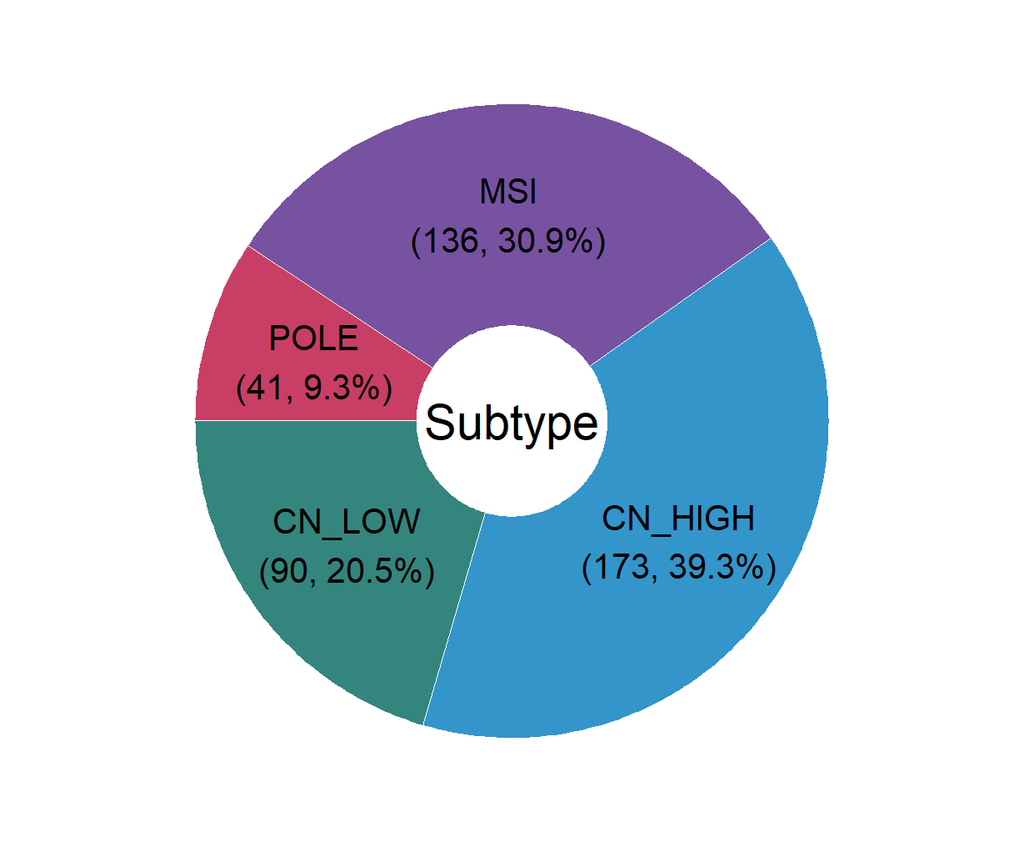

```r
# Subtype piechart --------------------------------------------------------
load('./Rdata/wgsdata.RData',verbose = T)
load('./Rdata/ucec_subtype_data.RData',verbose = T)
PieDonut_ztw(data = subtype_data %>% count(Subtype),ggplot2::aes(pies=Subtype,count=n),mainCol = subtype_color,start=3*pi/2,showNum = T,showRatioPie = TRUE,showRatioThreshold = 0.02,showDonutName = T,pieLabelSize=3.5,titlesize = 5,r0=0.3,title='AS_N', showPieName = TRUE,family = 'Roboto Condensed', labelpositionThreshold =0.02)
ggsave(filename = './Rscipts/Figures/Fig1a.png',width = 3,height = 3,device = cairo_pdf)
```

#Fig.1a, Distribution of UCEC tumors classified into four molecular subtypes based on WGS-derived genomic features: POLE (n = 41), MSI (n = 136), CN-High (n = 173), and CN-Low (n = 90).

## 5 Fig.1b

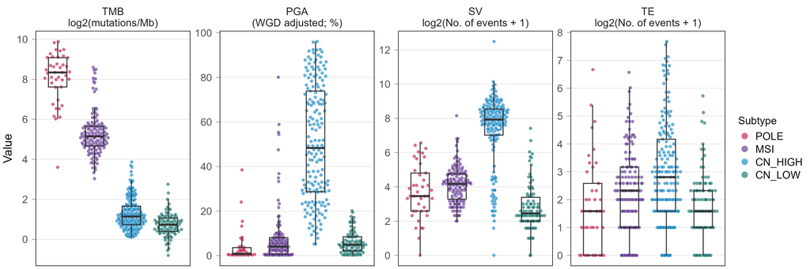

```r
# TMB/PGA/SV/TE --------------------------------------------------------------
load('./Rdata/ucec_subtype_data.RData')
load("./Rdata/ucec_burden.RData")

res_burden <- plot_group_compare(
  tdata       = ucec_burden,
  value       = value,
  group       = "Subtype",
  facet =     "name",
  FDR_facet = T,
  facet_ncol = 4,
  ylab        = "Value",
  hide_ns    = T,
  palette     = subtype_color,
  pcol_sig    = ncicolpal[1],
  facet_scales = 'free_y',
  output_file = "./Rscripts/Figures/Fig1b.png",
  y_pos_adjust = c(3,60,7,5),
  width       = 15,
  height      = 5,
  p_off = T
)
```

#Fig.1b, Genome-wide alteration metrics across UCEC molecular subtypes, including tumor mutational burden (TMB; log₂ mutations per megabase), proportion of genome altered (PGA; WGD-adjusted), structural variant (SV) burden (log₂ number of events + 1), and transposable element (TE) insertion burden (log₂ number of events + 1). Each point represents one tumor. Boxes show median and interquartile range; whiskers denote 1.5× interquartile range. Two-sided Wilcoxon rank-sum tests with FDR correction were used.

## 6 Fig.1c

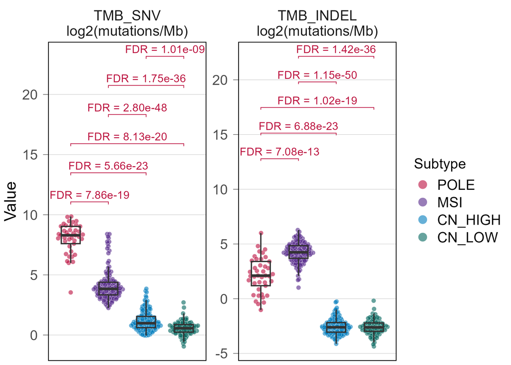

```r
## difference between SNV and indels
grch38 <- read_delim(
  './hg38.fa.fai',
  delim = '\t',
  col_names = FALSE
) #%>% slice(1:24)
grch38_size <- grch38 %>%
  filter(X1 %in% paste0('chr', c(1:22, 'X', 'Y', 'M'))) %>%
  summarise(total = sum(X2)) %>%
  pull(total)
tdata2 <- left_join(
  ucec_sbs96_profile %>% group_by(Tumor_Barcode) %>% summarise(TMB_SNV=sum(Contribution)) %>% mutate(TMB_SNV=log2(1e6*TMB_SNV/grch38_size)),
  ucec_id83_profile %>% group_by(Tumor_Barcode) %>% summarise(TMB_Indel=sum(Contribution)) %>% mutate(TMB_Indel=log2(1e6*TMB_Indel/grch38_size))
) %>%
  rename(`TMB_SNV\nlog2(mutations/Mb)`=TMB_SNV,`TMB_INDEL\nlog2(mutations/Mb)`=TMB_Indel) %>%
  pivot_longer(cols = -c(Tumor_Barcode)) %>%
  mutate(across(value, ~ replace_na(., 0))) %>%
  mutate(name=fct_inorder(name)) %>%
  left_join(subtype_data)

res_burden2 <- plot_group_compare(
  tdata       = tdata2,
  value       = value,
  group       = "Subtype",
  facet =     "name",
  FDR_facet = T,
  facet_ncol = 2,
  ylab        = "Value",
  hide_ns    = T,
  palette     = subtype_color,
  pcol_sig    = ncicolpal[1],
  facet_scales = 'free_y',
  output_file = "./Rscripts/Figures/Fig1c.png",
  #y_pos_adjust = c(3,60,7,5),
  width       = 7,
  height      = 5,
  #p_off = T
)
```

#Fig.1c, Genome-wide tumor mutational burden stratified by mutation class, showing separate contributions from single-nucleotide variants (SNVs) and small insertions and deletions (indels) across UCEC molecular subtypes (shown similarly to b).

## 7 Fig.1d

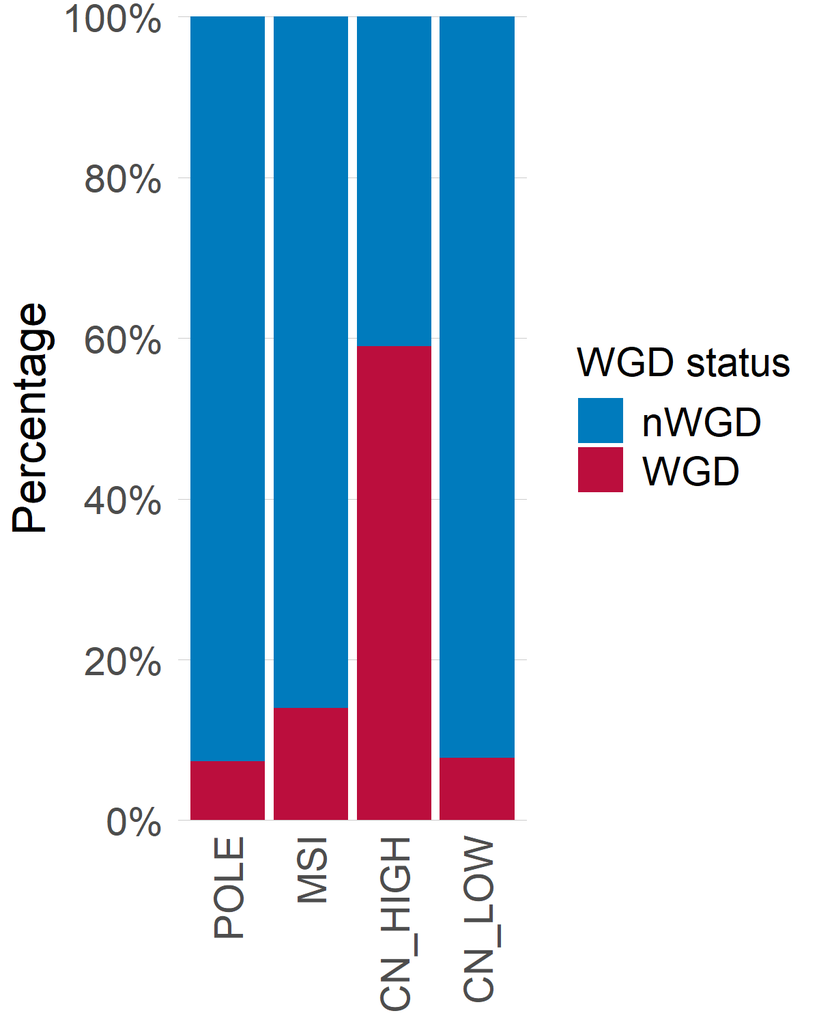

```r
# WGD ---------------------------------------------------------------------
load('./Rdata/MCN_data.RData',verbose = T)
load('./Rdata/ngspurity_data.RData')

subtype_data %>%
  left_join(MCN_data) %>%
  #mutate(WGD=if_else(WGD=='nWGD',WGD,if_else(WGD2=='WGD2','WGD2',WGD))) %>%
  count(Subtype,WGD) %>%
  group_by(Subtype) %>%
  mutate(n=n/sum(n)) %>%
  ggplot(ggplot2::aes(Subtype,n,fill=WGD))+
  geom_col()+
  scale_fill_manual(values = c('nWGD'='#007BBD','WGD'='#BB0E3D','WGD2'='#ff7f00'))+
  labs(x=NULL,y='Percentage',fill='WGD status')+
  scale_y_continuous(breaks = pretty_breaks(n = 7),labels = percent_format(),expand = expansion(mult = c(0,0)))+
  theme_ipsum_rc(axis_text_size = 14,axis_title_just = 'm',axis_title_size = 16,grid = 'Y',ticks = F)+
  theme(axis.text.x = element_text(angle = 90,vjust = 0.5,hjust = 1),
        #panel.spacing.x = unit(0.4,'cm'),
        axis.ticks.x = element_blank(),
        plot.margin = margin(6,4,4,4),
        #legend.position = 'bottom',
        legend.text = element_text(size = 14),
        legend.title = element_text(size = 14),
        strip.text.x = element_text(hjust = 0.5,face = 'bold',size = 16))


ggsave(filename = './Rscripts/Figures/Fig1d.png',width = 4,height = 5)
```

#Fig.1d, Fraction of WGD positive and WGD negative tumors within each molecular subtype.

## 8 Fig.1e

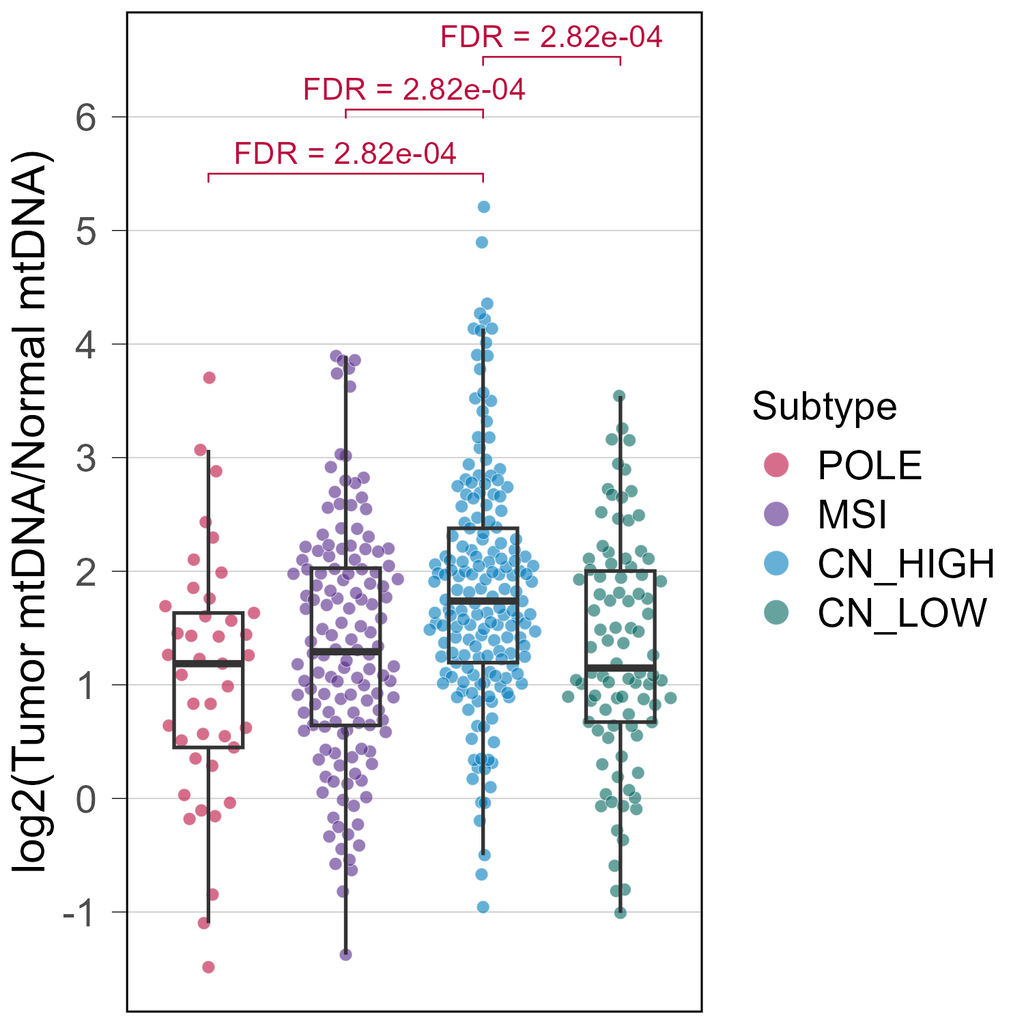

```r
# Mitochondria copy number ------------------------------------------------
load('./Rdata/mosdepth.RData',verbose = T)
load('./Rdata/ngspurity_data.RData',verbose = T)
load(file = './Rdata/wgsdata.RData',verbose = T)
load('./Rdata/wgs_clinical.RData',verbose = T)

tdata <- wgsdata %>%
  left_join(
    ngspurity %>%
      select(Tumor_Barcode, Tumor_Purity = BB_Purity, Tumor_Ploidy = BB_Ploidy)
  ) %>%
  left_join(
    mosdepth_mt %>% select(Tumor_Barcode = Barcode, Tumor_Ratio = Ratio)
  ) %>%
  left_join(
    mosdepth_mt %>% select(Normal_Barcode = Barcode, Normal_Ratio = Ratio)
  ) %>%
  mutate(R = (Tumor_Purity * Tumor_Ploidy + (1 - Tumor_Purity) * 2)) %>%
  mutate(Tumor_MT = Tumor_Ratio * R, Normal_MT = Normal_Ratio) %>%
  mutate(MT_Ratio = log2(Tumor_MT / Normal_MT)) %>%
  left_join(wgs_clinical %>% select(Subject,age_at_diagnosis)) %>%
  left_join(subtype_data)

tdata %>%
  ggplot(ggplot2::aes(x=MT_Ratio,y="Tumor")) +
  ggbeeswarm::geom_quasirandom(pch = 21, size = 2, width = 0.4, color = "black", stroke = 0.2,fill=ncicolpal[1],alpha=0.6) +
  ggplot2::geom_boxplot(width = 0.4, fill = NA, color = "gray20", outlier.shape = NA, size = 0.8) +
  scale_x_continuous(breaks = pretty_breaks(n=7))+
  labs(x = "log2(Tumor mtDNA/Normal mtDNA)", y = "Tumor") +
  theme_ipsum_rc(base_size = 13,axis_title_just = 'm', axis_title_size = 14,plot_margin = margin(5.5, 5.5, 5.5, 5.5), plot_title_size = 15,
                 ticks = T, axis = "X",grid = "X",axis_col = 'black') +
  theme( axis.text.y = element_blank(),axis.ticks.y = element_blank(),plot.margin = margin(4,4,4,4)
  ) + guides(fill = "none")

tdata %>% filter(MT_Ratio>0)

plot_group_compare(
  tdata       = tdata,
  value       = MT_Ratio,
  group       = "Subtype",
  ylab        = "log2(Tumor mtDNA/Normal mtDNA)",
  hide_ns    = TRUE,
  palette     = subtype_color,
  pcol_sig    = ncicolpal[1],
  output_file = "./Rscripts/figures/Fig1e.png",y_pos_adjust = c(1,5.5,3,5.7,5,5.8),
  width       = 5,
  height      = 5
)
```

#Fig.1e, Relative mitochondrial DNA (mtDNA) copy number across UCEC subtypes, expressed as log₂(tumor/normal mtDNA ratio). Statistical significance was assessed using two-sided Wilcoxon rank-sum tests with FDR correction.

## 9 Fig.1f

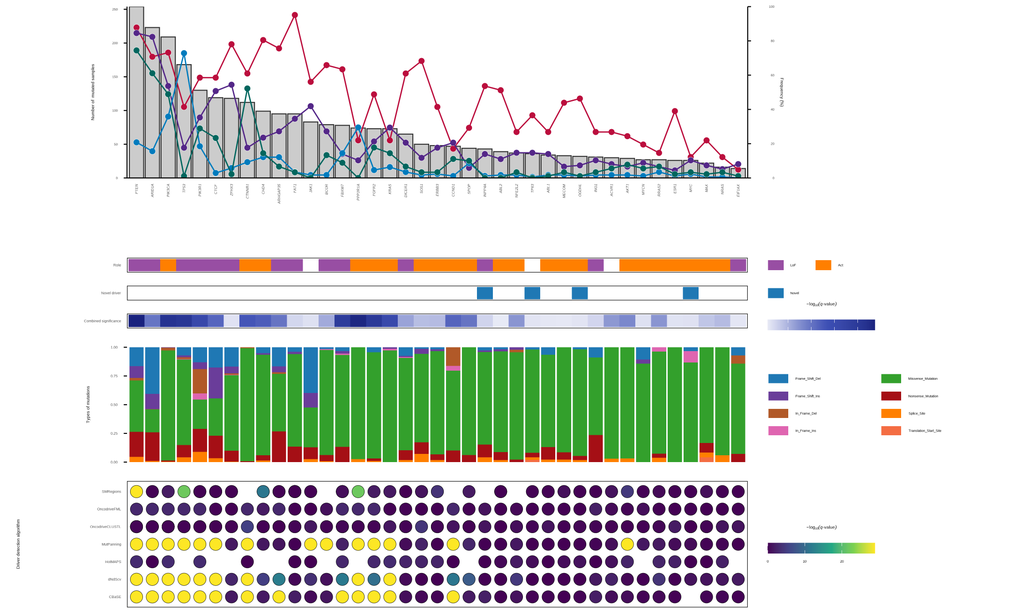

```r
# function
round_up_multiple <- function(x, bases = c(2,3,4,5)) {
  if (is.infinite(x) || is.na(x)) return(1)
  candidates <- sapply(bases, function(b) ceiling(x / b) * b)
  min(candidates)
}

combined_data <- read_delim('./drivers.tsv',delim = '\t',col_names = T) %>% filter(QVALUE_COMBINATION <0.1)
smregions_data <- read_delim('./intogene/output/steps/smregions/TCGA_WGS_UCEC.smregions.tsv.gz',delim = '\t')
oncodrivefml_data <- read_delim('./intogene/output/steps/oncodrivefml/out/TCGA_WGS_UCEC-oncodrivefml.tsv.gz',delim = '\t')
oncodriveclustl_data <- read_delim('./intogene/output/steps/oncodriveclustl/TCGA_WGS_UCEC/clusters_results.tsv',delim = '\t')
mutpanning_data <- read_delim('./intogene/output/steps/mutpanning/out/SignificanceFiltered/SignificanceTCGA_WGS_UCEC.txt',delim = '\t')
hotmaps_data <- read_delim('./intogene/output/steps/hotmaps/TCGA_WGS_UCEC.out.gz',delim = '\t')
dndscv_data <- read_delim('./intogene/output/steps/dndscv/TCGA_WGS_UCEC.dndscv.tsv.gz',delim = '\t')
cbase_data <- read_delim('./intogene/output/steps/cbase/TCGA_WGS_UCEC.cbase.tsv.gz',delim = '\t')

sigdata <- bind_rows(
  smregions_data %>% select(Gene=HUGO_SYMBOL,Q=Q_VALUE) %>% mutate(Method='SMRegions'),
  oncodrivefml_data %>% select(Gene=SYMBOL,Q=Q_VALUE) %>% mutate(Method='OncodriveFML'),
  oncodriveclustl_data %>% select(Gene=SYMBOL,Q=P) %>% mutate(Method='OncodriveCLUSTL'),
  mutpanning_data %>% select(Gene=Name,Q=FDR) %>% mutate(Method='MutPanning'),
  hotmaps_data %>% select(Gene=GENE,Q=`q-value`) %>% mutate(Method='HotMAPS'),
  dndscv_data %>% select(Gene=gene_name,Q=qglobal_cv) %>% mutate(Method='dNdScv'),
  cbase_data %>% select(Gene=gene,Q=q_pos) %>% mutate(Method='CBaSE')
) %>%
  filter(Gene %in% combined_data$SYMBOL)

# process Q-value 0
minmalQ <- sigdata %>% filter(Q>0) %>% arrange(Q) %>% slice(1) %>% pull(Q)
sigdata <- sigdata %>%
  mutate(Q=if_else(Q==0,minmalQ, Q))

# mutation type data
load('./Rdata/ucec_maf.RData',verbose = T)
load('./Rdata/ucec_subtype_data.RData',verbose = T)
mutdata <- ucec_maf %>%
  filter(Tumor_Barcode %in% subtype_data$Tumor_Barcode) %>%
  filter(Hugo_Symbol %in% combined_data$SYMBOL) %>%
  count(Hugo_Symbol,Variant_Classification)

# freqdata

freqdata <- ucec_maf %>%
  filter(Tumor_Barcode %in% subtype_data$Tumor_Barcode) %>%
  filter(Hugo_Symbol %in% combined_data$SYMBOL) %>%
  select(Subject,Hugo_Symbol) %>%
  unique() %>%
  left_join(subtype_data) %>%
  count(Subtype,Hugo_Symbol) %>%
  left_join(subtype_data %>% count(Subtype,name = 'Total')) %>%
  mutate(freq=n/Total) %>%
  select(-n,-Total) %>%
  pivot_wider(names_from = 'Subtype',values_from = 'freq',values_fill = 0)


freqdata <- ucec_maf %>%
  filter(Tumor_Barcode %in% subtype_data$Tumor_Barcode) %>%
  filter(Hugo_Symbol %in% combined_data$SYMBOL) %>%
  select(Subject,Hugo_Symbol) %>%
  unique() %>%
  count(Hugo_Symbol,name = 'nMutSamples') %>%
  left_join(freqdata)

#Visualization -----------------------------------------------------------
gene_levels <- freqdata %>% arrange(desc(nMutSamples)) %>% pull(Hugo_Symbol)

# scale for dual-axis alignment
max_val <- suppressWarnings(max(freqdata$nMutSamples, na.rm = TRUE))
scale_y <- round_up_multiple(max_val,bases = 1)
if (!is.finite(scale_y) || is.na(scale_y)) scale_y <- 1

p1 <- freqdata %>%
  mutate(Hugo_Symbol = factor(Hugo_Symbol,levels = gene_levels)) %>%
  ggplot()+
  geom_col(aes(Hugo_Symbol,nMutSamples),fill='#cccccc',col='gray20',linewidth=0.5)+
  geom_point(aes(x=Hugo_Symbol,y=POLE*scale_y),fill="#BB0E3D",pch=21,col='white',stroke=0.2,size=3)+
  geom_line(aes(x=Hugo_Symbol,y=POLE*scale_y),color="#BB0E3D",group=1)+
  geom_point(aes(x=Hugo_Symbol,y=MSI*scale_y),fill="#542788",pch=21,col='white',stroke=0.2,size=3)+
  geom_line(aes(x=Hugo_Symbol,y=MSI*scale_y),color="#542788",group=1)+
  geom_point(aes(x=Hugo_Symbol,y=CN_HIGH*scale_y),fill="#007BBD",pch=21,col='white',stroke=0.2,size=3)+
  geom_line(aes(x=Hugo_Symbol,y=CN_HIGH*scale_y),color="#007BBD",group=1)+
  geom_point(aes(x=Hugo_Symbol,y=CN_LOW*scale_y),fill="#01665e",pch=21,col='white',stroke=0.2,size=3)+
  geom_line(aes(x=Hugo_Symbol,y=CN_LOW*scale_y),color="#01665e",group=1)+
  scale_y_continuous(breaks = pretty_breaks(),expand = expansion(add = c(0,0)),limits = c(0,scale_y),
                     sec.axis = sec_axis(~./scale_y, name="Frequency (%)",breaks = pretty_breaks()(c(0,1)),labels = 100*pretty_breaks()(c(0,1))))+
  labs(x=NULL,y='Number of  mutated samples')+
  theme_minimal(base_size = 14)+
  theme(panel.grid = element_blank(),axis.text.x = element_text(size = 12,angle = 90,hjust = 1,vjust = 0.5,face = 'italic'),
        axis.ticks.y = element_line(linewidth = 0.5),axis.line = element_line(linewidth =0.5),legend.direction = 'vertical')

p2 <- combined_data %>%
  mutate(SYMBOL = factor(SYMBOL,levels = gene_levels)) %>%
  ggplot(aes(SYMBOL,"Role",fill=ROLE))+
  geom_tile()+
  labs(x=NULL,y=NULL,fill=NULL)+
  scale_fill_manual(values = c('LoF'='#984ea3','Act'='#ff7f00'),na.value = NA,breaks = c('LoF','Act'))+
  theme_minimal(base_size = 14)+
  theme(panel.grid = element_blank(),axis.text.x = element_blank(),legend.direction = 'horizontal',axis.text = element_text(size=12),legend.key.height = unit(0.4,'cm'))+
  panel_border(size = 0.5,color = 'black')


novel_genes <- c('MYC','TP63','OGDHL','INPP4A')
p3 <- combined_data %>%
  mutate(SYMBOL = factor(SYMBOL,levels = gene_levels)) %>%
  mutate(Novel=if_else(SYMBOL %in% novel_genes,'Novel',NA_character_)) %>%
  ggplot(aes(SYMBOL,"Novel driver",fill=Novel))+
  geom_tile()+
  labs(x=NULL,y=NULL,fill=NULL)+
  scale_fill_manual(values = c('Novel'='#1f78b4'),na.value = NA,breaks = 'Novel')+
  theme_minimal(base_size = 14)+
  theme(panel.grid = element_blank(),axis.text.x = element_blank(),legend.direction = 'horizontal',axis.text = element_text(size=12),legend.key.height = unit(0.4,'cm'))+
  panel_border(size = 0.5,color = 'black')

p4 <- combined_data %>%
  mutate(SYMBOL = factor(SYMBOL,levels = gene_levels)) %>%
  ggplot(aes(SYMBOL,"Combined significance",fill=-log10(QVALUE_COMBINATION)))+
  geom_tile()+
  labs(x=NULL,y=NULL,fill=expression(-log[10](italic(q) * "-value")))+
  scale_fill_material(palette = 'indigo')+
  theme_minimal(base_size = 14)+
  theme(panel.grid = element_blank(),axis.text.x = element_blank(),legend.direction = 'horizontal',axis.text = element_text(size=12),legend.key.height = unit(0.4,'cm'),legend.key.width = unit(0.8,'cm'))+
  panel_border(size = 0.5,color = 'black')+
  guides(fill = guide_colourbar(title.position="top", title.hjust = 0.5))


tmp <- read_csv('./oncoplot_colors.csv')
landscape_colors <- tmp$Color
names(landscape_colors) <- tmp$Name

p5 <- mutdata %>%
  mutate(Hugo_Symbol = factor(Hugo_Symbol,levels = gene_levels)) %>%
  ggplot(aes(Hugo_Symbol,n,fill=Variant_Classification))+
  geom_col(position = 'fill')+
  labs(x=NULL,y='Types of mutations',fill=NULL)+
  scale_fill_manual(values = landscape_colors)+
  theme_minimal(base_size = 14)+
  theme(panel.grid = element_blank(),axis.ticks.y = element_line(linewidth = 0.5),axis.text.x = element_blank(),legend.direction = 'horizontal',axis.text = element_text(size=12),legend.key.height = unit(0.4,'cm'),legend.key.width = unit(0.8,'cm'))+guides(fill=guide_legend(nrow = 4))


p6 <- sigdata %>%
  mutate(Gene = factor(Gene,levels = gene_levels)) %>%
  ggplot(aes(Gene,Method,fill=-log10(Q)))+
  geom_point(size = 6,pch=21,stroke=0.25)+
  labs(x=NULL,y='Driver detection algorithm',fill=expression(-log[10](italic(q) * "-value")))+
  scale_fill_viridis_c()+
  theme_minimal(base_size = 14)+
  theme(panel.grid = element_blank(),axis.text.x = element_blank(),legend.direction = 'horizontal',axis.text = element_text(size=12),legend.key.height = unit(0.4,'cm'),legend.key.width = unit(0.8,'cm'))+
  panel_border(size = 0.5,color = 'black')+
  guides(fill = guide_colourbar(title.position="top", title.hjust = 0.5))


p <- plot_grid(p1,p2,p3,p4,p5,p6,align = 'v',axis = 'lr',ncol = 1,rel_heights = c(9,1,1,1,5,5))

ggsave(filename = './Rscripts/figures/Fig1f.png',plot = p,width = 15,height = 9)
```

#Fig.1f, Significantly mutated driver genes identified using an integrative driver discovery framework. The upper panel shows the number of tumors harboring mutations in each gene, with subtype-specific frequencies indicated. Middle annotations summarize inferred functional roles, novelty, and combined statistical significance (−log₁₀ q value). The lower panel shows mutation class composition and support across multiple driver detection methods.

## 10 Fig.1g

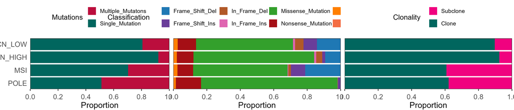

```r
library(maftools)
library(rstatix)
load('./Rdata/ucec_subtype_data.RData')
load('./Rdata/wgsdata.RData',verbose = T)
## load total MAF
load('./Rdata/ucec_maf.RData')

# Multiple mutations ------------------------------------------------------
drivers <- read_delim('./drivers.tsv',delim = '\t',col_names = T) %>% filter(QVALUE_COMBINATION<0.1)
# Multiple driver mutation frequency by subtype ---------------------------
tdata0 <- ucec_maf %>%
  filter(Hugo_Symbol %in% drivers$SYMBOL) %>%
  count(Tumor_Barcode,Hugo_Symbol) %>%
  left_join(subtype_data)

genelevs <- tdata0 %>% count(Hugo_Symbol,sort=T) %>% pull(Hugo_Symbol)

tmp <- read_csv('./oncoplot_colors.csv')
landscape_colors <- tmp$Color
names(landscape_colors) <- tmp$Name

tdata2 <- tdata0 %>%
  left_join(ucec_maf %>% select(Tumor_Barcode,Hugo_Symbol,Variant_Classification)) %>%
  count(Mmut=if_else(n>1,"Multiple_Mutatons","Single_Mutation"),Subtype,Gene_Name=Hugo_Symbol,Variant_Classification) %>%
  mutate(Gene_Name = factor(Gene_Name,levels = genelevs))

load('./Rdata/DP_info_data.RData',verbose = T)
tmp <- ucec_maf %>% filter(Hugo_Symbol %in% drivers$SYMBOL) %>% mutate(ID=paste(str_remove(Chromosome,'chr'),Start_Position,Reference_Allele,Tumor_Seq_Allele2,sep=':')) %>% select(Tumor_Barcode,ID,Variant_Classification2=Variant_Classification)
DP_info_data <- DP_info_data %>% filter(Gene_Name %in% drivers$SYMBOL)
DP_info_data <- DP_info_data %>% left_join(tmp) %>% filter(!is.na(Variant_Classification2))

tdata3 <- tdata0 %>%
  rename(Gene_Name=Hugo_Symbol) %>%
  left_join(DP_info_data %>% select(Tumor_Barcode,Gene_Name,Clone)) %>%
  count(Mmut=if_else(n>1,"Multiple_Mutatons","Single_Mutation"),Subtype,Gene_Name,Clone) %>%
  mutate(Gene_Name = factor(Gene_Name,levels = genelevs)) %>%
  filter(!is.na(Clone))

# summary plot

odata1 <- tdata0 %>%
  count(Subtype,Mmut=if_else(n>1,"Multiple_Mutatons","Single_Mutation"))

p1 <- odata1 %>%
  ggplot()+
  geom_col(aes(Subtype,n,fill=Mmut),position = 'fill')+
  #facet_grid(.~Subtype,scale="free_x",space = "free")+
  labs(x=NULL,y='Proportion',fill='Mutations')+
  scale_fill_manual(values = c("#BB0E3D","#01665e"))+
  scale_y_continuous(breaks = pretty_breaks(),expand = expansion(add = c(0,0)))+
  scale_x_discrete(expand = expansion(add=c(0,0)))+
  theme_ipsum_rc(base_size = 14,axis_title_size = 16,axis_title_just = 'm' ,axis = T,grid = FALSE,ticks = F)+
  theme(plot.margin = margin(6,4,4,4),panel.spacing = unit(x = 0.1,'cm'),panel.grid = element_blank(), axis.ticks.x = element_line(linewidth = 0.5),legend.direction = 'horizontal',legend.position = 'top',axis.line = element_blank())+
  guides(fill=guide_legend(nrow = 2))+
  panel_border(color = 'black',size=0.5)+
  coord_flip()

odata2 <- tdata2 %>% group_by(Subtype,Variant_Classification) %>% summarise(n=sum(n)) %>% ungroup()

p2 <- odata2 %>%
  ggplot(aes(Subtype,n,fill=Variant_Classification))+
  geom_col(position = 'fill')+
  #facet_wrap(~Mmut)+
  #facet_grid(Mmut~Subtype,scale="free_x",space = "free")+
  labs(x=NULL,y='Proportion',fill='Classification')+
  scale_fill_manual(values = landscape_colors)+
  scale_x_discrete(expand = expansion(add=c(0,0)))+
  scale_y_continuous(breaks = pretty_breaks(),expand = expansion(add = c(0,NA)))+
  theme_ipsum_rc(base_size = 14,axis_title_size = 16,axis_title_just = 'm' ,axis = T,grid = FALSE,ticks = F)+
  theme(plot.margin = margin(6,4,4,4),panel.spacing = unit(x = 0.1,'cm'),panel.grid = element_blank(),axis.text.y=element_blank(),axis.ticks.x = element_line(linewidth = 0.5),legend.direction = 'horizontal',legend.position = 'top',axis.line = element_blank(),strip.text.x = element_blank())+
  guides(fill=guide_legend(nrow = 2))+
  panel_border(color = 'black',size=0.5)+
  coord_flip()

odata3 <- tdata3 %>% group_by(Subtype,Clone) %>% summarise(n=sum(n)) %>% ungroup()

p3 <- odata3 %>%
  ggplot(aes(Subtype,n,fill=Clone))+
  geom_col(position = 'fill')+
  #facet_grid(Mmut~Subtype,scale="free_x",space = "free")+
  labs(x=NULL,y='Proportion',fill='Clonality')+
  scale_fill_manual(values = c(N="#f0027f",Y='#01665e'),labels=c('Subclone','Clone'))+
  scale_x_discrete(expand = expansion(add=c(0,0)))+
  scale_y_continuous(breaks = pretty_breaks(),expand = expansion(add = c(0,NA)))+
  theme_ipsum_rc(base_size = 14,axis_title_size = 16,axis_title_just = 'm' ,axis = T,grid = FALSE,ticks = F)+
  theme(plot.margin = margin(6,4,4,4),panel.spacing = unit(x = 0.1,'cm'),panel.grid = element_blank(),axis.text.y = element_blank(),axis.ticks.x = element_line(linewidth = 0.5),legend.direction = 'horizontal',legend.position = 'top',axis.line = element_blank(),strip.text.x = element_blank())+
  guides(fill=guide_legend(nrow = 2,))+
  panel_border(color = 'black',size=0.5)+
  coord_flip()

plot_grid(p1,p2,p3,align = 'h',axis = 'tb',nrow = 1)
ggsave(filename = './Rscripts/Figures/Fig1g.png',width = 14,height = 3)
```

#Fig.1g,Subtype-specific properties of driver gene alterations, including the proportion of genes affected by single versus multiple-hit mutations, distribution of mutation classifications, and fraction of clonal versus subclonal events.